# CSC6621 Project 2

## Dense Neural Networks and Convolutional Neural Networks

```python
import numpy as np
import tensorflow as tf
from sklearn.model_selection import train_test_split
from sklearn.metrics import classification_report, confusion_matrix
import matplotlib.pyplot as plt
from tensorflow.keras import models
from tensorflow.keras.layers import InputLayer, Flatten, Dense, Conv2D, MaxPooling2D
import seaborn as sns
```

```python
the_answer = 42
np.random.seed(the_answer)
tf.random.set_seed(the_answer)
```

## Helpers

```python
def test_predict_evaluate(x_test, y_test, model):
    y_pred = model.predict(x_test)

    # Convert predictions from one-hot encoding to class labels
    y_pred_classes = np.argmax(y_pred, axis=1)
    y_test_classes = np.argmax(y_test, axis=1)

    # Evaluate the model on the test set
    test_loss, test_accuracy = model.evaluate(x_test, y_test)
    print(f"Test Loss: {test_loss:.4f}")
    print(f"Test Accuracy: {test_accuracy:.4f}")

    # Print a classification report (precision, recall, F1-score per class)
    print(classification_report(y_test_classes, y_pred_classes))

    cm = confusion_matrix(y_test_classes, y_pred_classes)

    # Visualize the confusion matrix using seaborn heatmap
    plt.figure(figsize=(7, 5))
    sns.heatmap(cm, annot=True, fmt='d', cmap='Blues', xticklabels=np.arange(10), yticklabels=np.arange(10))
    plt.title('Confusion Matrix')
    plt.xlabel('Predicted Labels')
    plt.ylabel('True Labels')
    plt.show()

    # Visualizing incorrectly predicted samples
    incorrect_indices = np.where(y_pred_classes != y_test_classes)[0]

    # Choose 24 random incorrect predictions to visualize
    incorrect_sample_indices = np.random.choice(incorrect_indices, 24, replace=False)

    # Plot the incorrectly predicted samples
    plt.figure(figsize=(8, 16))
    for i, idx in enumerate(incorrect_sample_indices):
        plt.subplot(8, 3, i+1)
        plt.imshow(x_test[idx].reshape(28, 28), cmap='gray')
        plt.title(f"True: {y_test_classes[idx]}, Pred: {y_pred_classes[idx]}")
        plt.axis('off')

    plt.tight_layout()
    plt.show()

def plot_convergence_history(history):
    train_loss = history.history["loss"]
    val_loss = history.history["val_loss"]
    train_accuracy = history.history["accuracy"]
    val_accuracy = history.history["val_accuracy"]

    # Create subplots
    fig, axs = plt.subplots(1, 2, figsize=(14, 5))

    # Plot training and validation loss
    axs[0].plot(train_loss, label="Training Loss")
    axs[0].plot(val_loss, label="Validation Loss")
    axs[0].set_title("Training and Validation Loss")
    axs[0].set_xlabel("Epochs")
    axs[0].set_ylabel("Loss")
    axs[0].legend()

    # Plot training and validation accuracy
    axs[1].plot(train_accuracy, label="Training Accuracy")
    axs[1].plot(val_accuracy, label="Validation Accuracy")
    axs[1].set_title("Training and Validation Accuracy")
    axs[1].set_xlabel("Epochs")
    axs[1].set_ylabel("Accuracy")
    axs[1].legend()

    # Show the plot
    plt.tight_layout()
    plt.show()

def compile_fit_evaluate_cnn(
    x_train,
    y_train,
    x_val,
    y_val,
    layers,
    optimizer,
    epochs,
    evaluations,
    key_prefix,
):
    model = compile_summarize_cnn(layers, optimizer)
    fit_visualize_convergence(model, x_train, y_train, x_val, y_val, epochs)
    evaluate_record_metrics(model, x_val, y_val, evaluations, f"{key_prefix}_CNN")
    return model, evaluations

def compile_fit_evaluate_dnn(
    x_train,
    y_train,
    x_val,
    y_val,
    layers,
    optimizer,
    epochs,
    evaluations,
    key_prefix,
):
    model = compile_summarize_dnn(layers, optimizer)
    fit_visualize_convergence(model, x_train, y_train, x_val, y_val, epochs)
    evaluate_record_metrics(model, x_val, y_val, evaluations, f"{key_prefix}_DNN")
    return model, evaluations

def compile_summarize_cnn(hidden_layers, optimizer):
    model = models.Sequential(
        [
            InputLayer(input_shape=(28, 28, 1)),
            *hidden_layers,
            Dense(10, activation="softmax"),
        ]
    )
    model.compile(
        optimizer=optimizer,
        loss="categorical_crossentropy",
        metrics=["accuracy"],
    )
    model.summary()
    return model

def compile_summarize_dnn(hidden_layers, optimizer):
    model = models.Sequential(
        [
            InputLayer(input_shape=(28, 28, 1)),
            Flatten(),
            *hidden_layers,
            Dense(10, activation="softmax"),
        ]
    )
    model.compile(
        optimizer=optimizer,
        loss="categorical_crossentropy",
        metrics=["accuracy"],
    )
    model.summary()
    return model


def fit_visualize_convergence(
    model,
    x_train,
    y_train,
    x_val,
    y_val,
    epochs,
):
    history = model.fit(
        x_train,
        y_train,
        epochs=epochs,
        batch_size=128,
        validation_data=(x_val, y_val),
        verbose=0,
    )
    plot_convergence_history(history)


def evaluate_record_metrics(model, x_val, y_val, evaluations, key):
    loss, accuracy = model.evaluate(x_val, y_val, verbose=0)
    evaluations[key] = {"loss": loss, "accuracy": accuracy}
```

### Load and Visualize the Data

*Load the data.*

```python
with np.load("kmnist-train-imgs.npz") as train_imgs, np.load(
    "kmnist-train-labels.npz"
) as train_labels, np.load("kmnist-train-imgs.npz") as test_imgs, np.load(
    "kmnist-train-labels.npz"
) as test_labels:
    x_train_full = train_imgs["arr_0"]
    y_train_full = train_labels["arr_0"]
    x_test = test_imgs["arr_0"]
    y_test = test_labels["arr_0"]

x_train, x_val, y_train, y_val = train_test_split(
    x_train_full,
    y_train_full,
    test_size=0.2,
    random_state=the_answer,
    stratify=y_train_full,
)

y_train = tf.keras.utils.to_categorical(y_train)
y_val = tf.keras.utils.to_categorical(y_val)
y_test = tf.keras.utils.to_categorical(y_test)
```

*Plot 3 examples from 4 of the classes.*

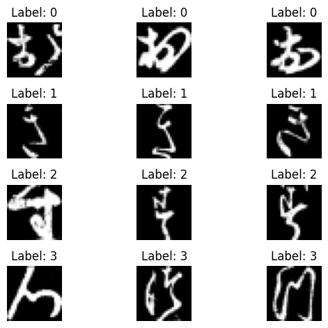

```python
train_labels = np.argmax(y_train, axis=1)
unique_labels = np.unique(train_labels)
for i, cls in enumerate(unique_labels[:4]):
    cls_mask = train_labels == cls
    three_examples = x_train[cls_mask][:3]
    for j in range(len(three_examples)):
        plt.subplot(4, 3, i * 3 + j + 1)
        plt.imshow(three_examples[j], cmap="gray")
        plt.axis("off")
        plt.title(f"Label: {cls}")

plt.tight_layout()
plt.show()
```

*Reshape the images into 4D tensors of shape (N, 28, 28, 1). The first dimension (N) represents the number of images. Each image is 28x28 pixels. Since the images are grayscale, they only have 1 channel.*

```python
print(f"x_train shape: {x_train.shape}")
print(f"x_test shape: {x_test.shape}")

x_train = x_train.reshape(-1, 28, 28, 1)
x_val = x_val.reshape(-1, 28, 28, 1)
x_test = x_test.reshape(-1, 28, 28, 1)

print(f"x_train reshape: {x_train.shape}")
print(f"x_test reshape: {x_test.shape}")
```

```
x_train shape: (48000, 28, 28)
x_test shape: (60000, 28, 28)
x_train reshape: (48000, 28, 28, 1)
x_test reshape: (60000, 28, 28, 1)
```

*The tensors represent the 256 possible gray colors using integer values (e.g., 0, 1, 2, . . . , 255). Convert the tensors to 32-bit floats and divide by 255 to scale the pixels to the range of [0, 1].*

```python
x_train = x_train.astype('float32') / 255
x_val = x_val.astype('float32') / 255
x_test = x_test.astype('float32') / 255
```

### Implement a Multi-Layer Perceptron / Fully Connected Feedforward Neural Network as a baseline

*Is this a binary or multiclass classification problem?*

This is a multiclass classification problem.

*Review the probabilistic loss functions available in Keras and determine which loss function is most appropriate.*

We've explored several loss functions of Keras. MSE, binary_crossentropy, categorical_crossentropy, and sparse_categorical_crossentropy. Since this is a classification problem, it is multiclass, and our data is one-hot encoded, categorical_crossentropy is best.

*Review and pick one of the optimizers available in Keras.*

We'll go with Adam.

*Implement a neural network using the Keras Sequential Model API with:*

```python
model = models.Sequential()
```

1. *input layer*

```python
model.add(InputLayer(input_shape=(28, 28, 1)))
```

2. *flatten layer*

```python
model.add(Flatten())
```

3. *2 dense layers of 8 nodes each (ReLU)*

```python
model.add(Dense(8, activation='relu'))
model.add(Dense(8, activation='relu'))
```

4. *1 dense layer of 10 nodes (why?) and a softmax activation function*

```python
# Output layer with 10 nodes because we have 10 classes.
model.add(Dense(10, activation='softmax'))
```

*Use the compile() method to build the model with your chosen loss function, optimizer, and metric. Use accuracy for the metric.*

```python
model.compile(optimizer='adam', loss='categorical_crossentropy', metrics=['accuracy'])
```

*Output a summary of the model architecture using the summary() method.*

```python
model.summary()
```

```
Model: "sequential_1"
```

```
┏━━━━━━━━━━━━━━━━━━━━━━━━━━━━━━━━━┳━━━━━━━━━━━━━━━━━━━━━━━━┳━━━━━━━━━━━━━━━┓
┃ Layer (type)                    ┃ Output Shape           ┃       Param # ┃
┡━━━━━━━━━━━━━━━━━━━━━━━━━━━━━━━━━╇━━━━━━━━━━━━━━━━━━━━━━━━╇━━━━━━━━━━━━━━━┩
│ flatten_2 (Flatten)             │ (None, 784)            │             0 │
├─────────────────────────────────┼────────────────────────┼───────────────┤
│ dense_5 (Dense)                 │ (None, 8)              │         6,280 │
├─────────────────────────────────┼────────────────────────┼───────────────┤
│ dense_6 (Dense)                 │ (None, 8)              │            72 │
├─────────────────────────────────┼────────────────────────┼───────────────┤
│ dense_7 (Dense)                 │ (None, 10)             │            90 │
└─────────────────────────────────┴────────────────────────┴───────────────┘
```

```
 Total params: 6,442 (25.16 KB)
```

```
 Trainable params: 6,442 (25.16 KB)
```

```
 Non-trainable params: 0 (0.00 B)
```

*Use the fit() method to train the model. Start with 10 epochs.*

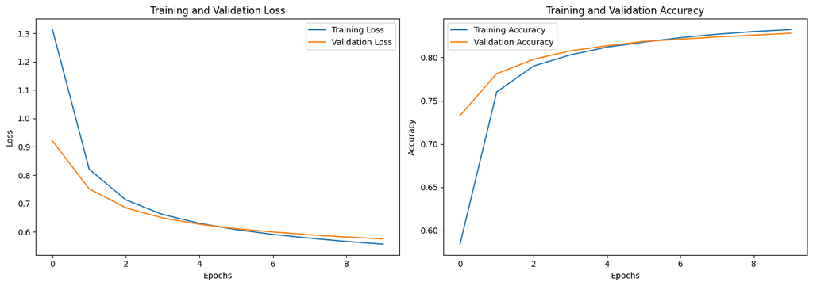

```python
fit_visualize_convergence(model, x_train, y_train, x_val, y_val, epochs=10)
```

```python
evaluations = {}
evaluate_record_metrics(model, x_val, y_val, evaluations, 'baseline')
```

*Optimize the validation accuracy of the model by trying different choices for the number of training epochs, the number of hidden dense layers (e.g. 0, 1, 2, 3, etc.), the number of neurons in the first two dense layers, and the optimizer. Record the results your experimentation and include them in your lab report.*

### Optimizer

```
Model: "sequential_68"
```

```
┏━━━━━━━━━━━━━━━━━━━━━━━━━━━━━━━━━┳━━━━━━━━━━━━━━━━━━━━━━━━┳━━━━━━━━━━━━━━━┓
┃ Layer (type)                    ┃ Output Shape           ┃       Param # ┃
┡━━━━━━━━━━━━━━━━━━━━━━━━━━━━━━━━━╇━━━━━━━━━━━━━━━━━━━━━━━━╇━━━━━━━━━━━━━━━┩
│ flatten_73 (Flatten)            │ (None, 784)            │             0 │
├─────────────────────────────────┼────────────────────────┼───────────────┤
│ dense_200 (Dense)               │ (None, 8)              │         6,280 │
├─────────────────────────────────┼────────────────────────┼───────────────┤
│ dense_201 (Dense)               │ (None, 8)              │            72 │
├─────────────────────────────────┼────────────────────────┼───────────────┤
│ dense_202 (Dense)               │ (None, 10)             │            90 │
└─────────────────────────────────┴────────────────────────┴───────────────┘
```

```
 Total params: 6,442 (25.16 KB)
```

```
 Trainable params: 6,442 (25.16 KB)
```

```
 Non-trainable params: 0 (0.00 B)
```

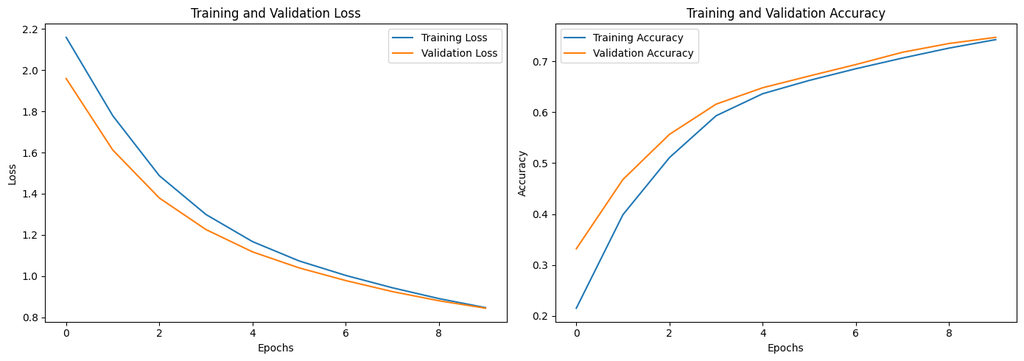

```
Model: "sequential_69"
```

```
┏━━━━━━━━━━━━━━━━━━━━━━━━━━━━━━━━━┳━━━━━━━━━━━━━━━━━━━━━━━━┳━━━━━━━━━━━━━━━┓
┃ Layer (type)                    ┃ Output Shape           ┃       Param # ┃
┡━━━━━━━━━━━━━━━━━━━━━━━━━━━━━━━━━╇━━━━━━━━━━━━━━━━━━━━━━━━╇━━━━━━━━━━━━━━━┩
│ flatten_74 (Flatten)            │ (None, 784)            │             0 │
├─────────────────────────────────┼────────────────────────┼───────────────┤
│ dense_203 (Dense)               │ (None, 8)              │         6,280 │
├─────────────────────────────────┼────────────────────────┼───────────────┤
│ dense_204 (Dense)               │ (None, 8)              │            72 │
├─────────────────────────────────┼────────────────────────┼───────────────┤
│ dense_205 (Dense)               │ (None, 10)             │            90 │
└─────────────────────────────────┴────────────────────────┴───────────────┘
```

```
 Total params: 6,442 (25.16 KB)
```

```
 Trainable params: 6,442 (25.16 KB)
```

```
 Non-trainable params: 0 (0.00 B)
```

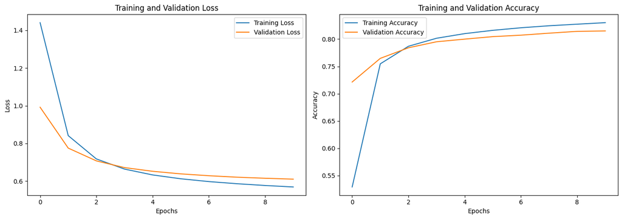

```
Model: "sequential_70"
```

```
┏━━━━━━━━━━━━━━━━━━━━━━━━━━━━━━━━━┳━━━━━━━━━━━━━━━━━━━━━━━━┳━━━━━━━━━━━━━━━┓
┃ Layer (type)                    ┃ Output Shape           ┃       Param # ┃
┡━━━━━━━━━━━━━━━━━━━━━━━━━━━━━━━━━╇━━━━━━━━━━━━━━━━━━━━━━━━╇━━━━━━━━━━━━━━━┩
│ flatten_75 (Flatten)            │ (None, 784)            │             0 │
├─────────────────────────────────┼────────────────────────┼───────────────┤
│ dense_206 (Dense)               │ (None, 8)              │         6,280 │
├─────────────────────────────────┼────────────────────────┼───────────────┤
│ dense_207 (Dense)               │ (None, 8)              │            72 │
├─────────────────────────────────┼────────────────────────┼───────────────┤
│ dense_208 (Dense)               │ (None, 10)             │            90 │
└─────────────────────────────────┴────────────────────────┴───────────────┘
```

```
 Total params: 6,442 (25.16 KB)
```

```
 Trainable params: 6,442 (25.16 KB)
```

```
 Non-trainable params: 0 (0.00 B)
```

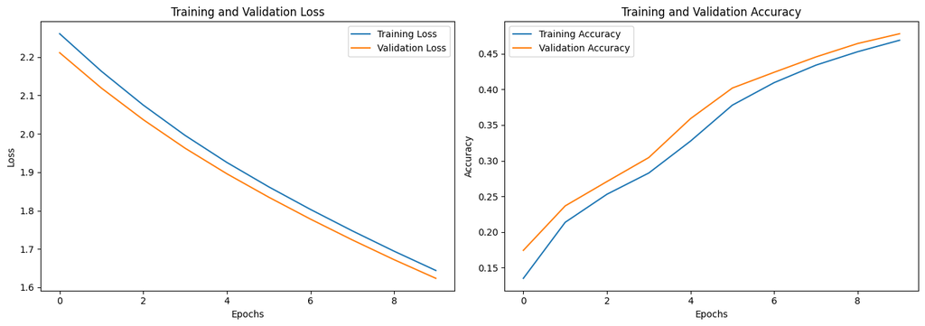

```
Model: "sequential_71"
```

```
┏━━━━━━━━━━━━━━━━━━━━━━━━━━━━━━━━━┳━━━━━━━━━━━━━━━━━━━━━━━━┳━━━━━━━━━━━━━━━┓
┃ Layer (type)                    ┃ Output Shape           ┃       Param # ┃
┡━━━━━━━━━━━━━━━━━━━━━━━━━━━━━━━━━╇━━━━━━━━━━━━━━━━━━━━━━━━╇━━━━━━━━━━━━━━━┩
│ flatten_76 (Flatten)            │ (None, 784)            │             0 │
├─────────────────────────────────┼────────────────────────┼───────────────┤
│ dense_209 (Dense)               │ (None, 8)              │         6,280 │
├─────────────────────────────────┼────────────────────────┼───────────────┤
│ dense_210 (Dense)               │ (None, 8)              │            72 │
├─────────────────────────────────┼────────────────────────┼───────────────┤
│ dense_211 (Dense)               │ (None, 10)             │            90 │
└─────────────────────────────────┴────────────────────────┴───────────────┘
```

```
 Total params: 6,442 (25.16 KB)
```

```
 Trainable params: 6,442 (25.16 KB)
```

```
 Non-trainable params: 0 (0.00 B)
```

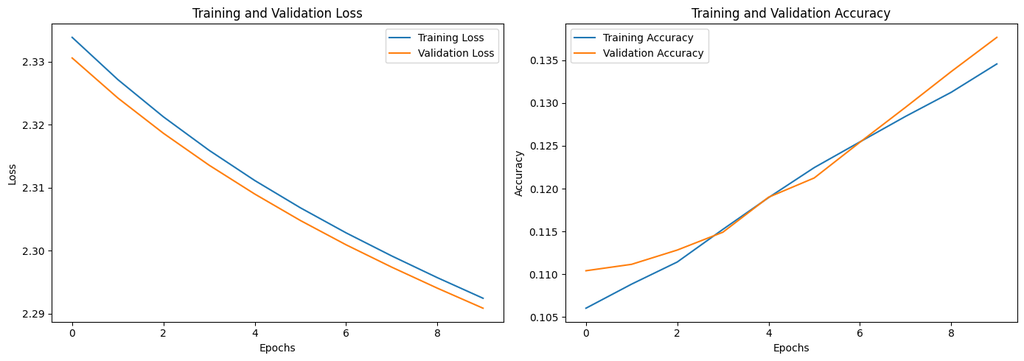

```
Model: "sequential_72"
```

```
┏━━━━━━━━━━━━━━━━━━━━━━━━━━━━━━━━━┳━━━━━━━━━━━━━━━━━━━━━━━━┳━━━━━━━━━━━━━━━┓
┃ Layer (type)                    ┃ Output Shape           ┃       Param # ┃
┡━━━━━━━━━━━━━━━━━━━━━━━━━━━━━━━━━╇━━━━━━━━━━━━━━━━━━━━━━━━╇━━━━━━━━━━━━━━━┩
│ flatten_77 (Flatten)            │ (None, 784)            │             0 │
├─────────────────────────────────┼────────────────────────┼───────────────┤
│ dense_212 (Dense)               │ (None, 8)              │         6,280 │
├─────────────────────────────────┼────────────────────────┼───────────────┤
│ dense_213 (Dense)               │ (None, 8)              │            72 │
├─────────────────────────────────┼────────────────────────┼───────────────┤
│ dense_214 (Dense)               │ (None, 10)             │            90 │
└─────────────────────────────────┴────────────────────────┴───────────────┘
```

```
 Total params: 6,442 (25.16 KB)
```

```
 Trainable params: 6,442 (25.16 KB)
```

```
 Non-trainable params: 0 (0.00 B)
```

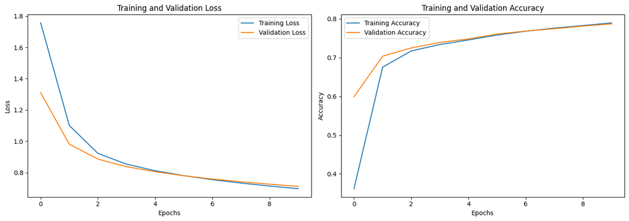

```
Model: "sequential_73"
```

```
┏━━━━━━━━━━━━━━━━━━━━━━━━━━━━━━━━━┳━━━━━━━━━━━━━━━━━━━━━━━━┳━━━━━━━━━━━━━━━┓
┃ Layer (type)                    ┃ Output Shape           ┃       Param # ┃
┡━━━━━━━━━━━━━━━━━━━━━━━━━━━━━━━━━╇━━━━━━━━━━━━━━━━━━━━━━━━╇━━━━━━━━━━━━━━━┩
│ flatten_78 (Flatten)            │ (None, 784)            │             0 │
├─────────────────────────────────┼────────────────────────┼───────────────┤
│ dense_215 (Dense)               │ (None, 8)              │         6,280 │
├─────────────────────────────────┼────────────────────────┼───────────────┤
│ dense_216 (Dense)               │ (None, 8)              │            72 │
├─────────────────────────────────┼────────────────────────┼───────────────┤
│ dense_217 (Dense)               │ (None, 10)             │            90 │
└─────────────────────────────────┴────────────────────────┴───────────────┘
```

```
 Total params: 6,442 (25.16 KB)
```

```
 Trainable params: 6,442 (25.16 KB)
```

```
 Non-trainable params: 0 (0.00 B)
```

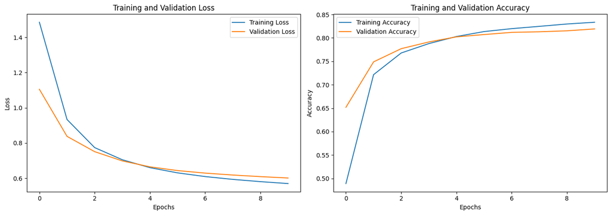

```
Model: "sequential_74"
```

```
┏━━━━━━━━━━━━━━━━━━━━━━━━━━━━━━━━━┳━━━━━━━━━━━━━━━━━━━━━━━━┳━━━━━━━━━━━━━━━┓
┃ Layer (type)                    ┃ Output Shape           ┃       Param # ┃
┡━━━━━━━━━━━━━━━━━━━━━━━━━━━━━━━━━╇━━━━━━━━━━━━━━━━━━━━━━━━╇━━━━━━━━━━━━━━━┩
│ flatten_79 (Flatten)            │ (None, 784)            │             0 │
├─────────────────────────────────┼────────────────────────┼───────────────┤
│ dense_218 (Dense)               │ (None, 8)              │         6,280 │
├─────────────────────────────────┼────────────────────────┼───────────────┤
│ dense_219 (Dense)               │ (None, 8)              │            72 │
├─────────────────────────────────┼────────────────────────┼───────────────┤
│ dense_220 (Dense)               │ (None, 10)             │            90 │
└─────────────────────────────────┴────────────────────────┴───────────────┘
```

```
 Total params: 6,442 (25.16 KB)
```

```
 Trainable params: 6,442 (25.16 KB)
```

```
 Non-trainable params: 0 (0.00 B)
```

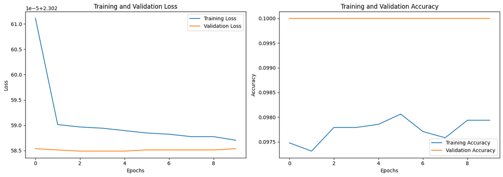

```python
optimizers = [
    'sgd',
    'rmsprop',
    'adagrad',
    'adadelta',
    'adamax',
    'nadam',
    'ftrl'
]

for optimizer in optimizers:
    model, evaluations = compile_fit_evaluate_dnn(
        x_train,
        y_train,
        x_val,
        y_val,
        [
            Dense(8, activation='relu'),
            Dense(8, activation='relu'),
        ],
        optimizer,
        10,
        evaluations,
        optimizer,
    )
```

### Layers

```
Model: "sequential_75"
```

```
┏━━━━━━━━━━━━━━━━━━━━━━━━━━━━━━━━━┳━━━━━━━━━━━━━━━━━━━━━━━━┳━━━━━━━━━━━━━━━┓
┃ Layer (type)                    ┃ Output Shape           ┃       Param # ┃
┡━━━━━━━━━━━━━━━━━━━━━━━━━━━━━━━━━╇━━━━━━━━━━━━━━━━━━━━━━━━╇━━━━━━━━━━━━━━━┩
│ flatten_80 (Flatten)            │ (None, 784)            │             0 │
├─────────────────────────────────┼────────────────────────┼───────────────┤
│ dense_225 (Dense)               │ (None, 10)             │         7,850 │
└─────────────────────────────────┴────────────────────────┴───────────────┘
```

```
 Total params: 7,850 (30.66 KB)
```

```
 Trainable params: 7,850 (30.66 KB)
```

```
 Non-trainable params: 0 (0.00 B)
```

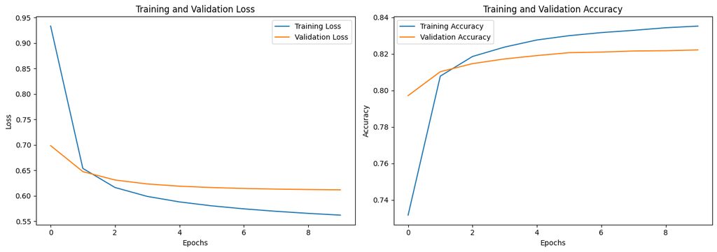

```
Model: "sequential_76"
```

```
┏━━━━━━━━━━━━━━━━━━━━━━━━━━━━━━━━━┳━━━━━━━━━━━━━━━━━━━━━━━━┳━━━━━━━━━━━━━━━┓
┃ Layer (type)                    ┃ Output Shape           ┃       Param # ┃
┡━━━━━━━━━━━━━━━━━━━━━━━━━━━━━━━━━╇━━━━━━━━━━━━━━━━━━━━━━━━╇━━━━━━━━━━━━━━━┩
│ flatten_81 (Flatten)            │ (None, 784)            │             0 │
├─────────────────────────────────┼────────────────────────┼───────────────┤
│ dense_221 (Dense)               │ (None, 8)              │         6,280 │
├─────────────────────────────────┼────────────────────────┼───────────────┤
│ dense_226 (Dense)               │ (None, 10)             │            90 │
└─────────────────────────────────┴────────────────────────┴───────────────┘
```

```
 Total params: 6,370 (24.88 KB)
```

```
 Trainable params: 6,370 (24.88 KB)
```

```
 Non-trainable params: 0 (0.00 B)
```

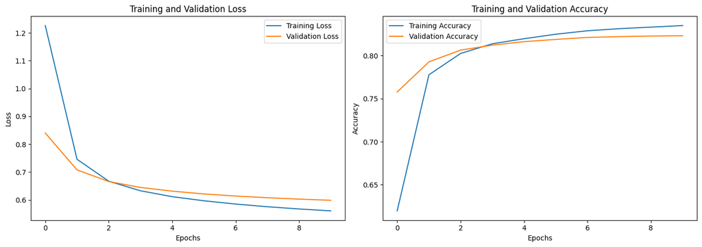

```
Model: "sequential_77"
```

```
┏━━━━━━━━━━━━━━━━━━━━━━━━━━━━━━━━━┳━━━━━━━━━━━━━━━━━━━━━━━━┳━━━━━━━━━━━━━━━┓
┃ Layer (type)                    ┃ Output Shape           ┃       Param # ┃
┡━━━━━━━━━━━━━━━━━━━━━━━━━━━━━━━━━╇━━━━━━━━━━━━━━━━━━━━━━━━╇━━━━━━━━━━━━━━━┩
│ flatten_82 (Flatten)            │ (None, 784)            │             0 │
├─────────────────────────────────┼────────────────────────┼───────────────┤
│ dense_222 (Dense)               │ (None, 8)              │         6,280 │
├─────────────────────────────────┼────────────────────────┼───────────────┤
│ dense_223 (Dense)               │ (None, 8)              │            72 │
├─────────────────────────────────┼────────────────────────┼───────────────┤
│ dense_224 (Dense)               │ (None, 8)              │            72 │
├─────────────────────────────────┼────────────────────────┼───────────────┤
│ dense_227 (Dense)               │ (None, 10)             │            90 │
└─────────────────────────────────┴────────────────────────┴───────────────┘
```

```
 Total params: 6,514 (25.45 KB)
```

```
 Trainable params: 6,514 (25.45 KB)
```

```
 Non-trainable params: 0 (0.00 B)
```

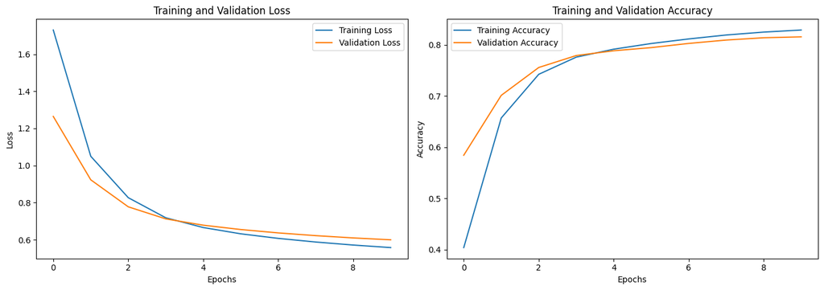

```python
hidden_layer_sets = [
    {"key": "0_hidden_layers", "hidden_layers": []},
    {"key": "1_hidden_layer", "hidden_layers": [Dense(8, activation="relu")]},
    {
        "key": "3_hidden_layers",
        "hidden_layers": [
            Dense(8, activation="relu"),
            Dense(8, activation="relu"),
            Dense(8, activation="relu"),
        ],
    },
]

for hidden_layer_set in hidden_layer_sets:
    model, evaluations = compile_fit_evaluate_dnn(
        x_train,
        y_train,
        x_val,
        y_val,
        hidden_layer_set["hidden_layers"],
        "adam",
        10,
        evaluations,
        hidden_layer_set["key"],
    )
```

# Nodes

```
Model: "sequential_78"
```

```
┏━━━━━━━━━━━━━━━━━━━━━━━━━━━━━━━━━┳━━━━━━━━━━━━━━━━━━━━━━━━┳━━━━━━━━━━━━━━━┓
┃ Layer (type)                    ┃ Output Shape           ┃       Param # ┃
┡━━━━━━━━━━━━━━━━━━━━━━━━━━━━━━━━━╇━━━━━━━━━━━━━━━━━━━━━━━━╇━━━━━━━━━━━━━━━┩
│ flatten_83 (Flatten)            │ (None, 784)            │             0 │
├─────────────────────────────────┼────────────────────────┼───────────────┤
│ dense_228 (Dense)               │ (None, 16)             │        12,560 │
├─────────────────────────────────┼────────────────────────┼───────────────┤
│ dense_229 (Dense)               │ (None, 8)              │           136 │
├─────────────────────────────────┼────────────────────────┼───────────────┤
│ dense_230 (Dense)               │ (None, 10)             │            90 │
└─────────────────────────────────┴────────────────────────┴───────────────┘
```

```
 Total params: 12,786 (49.95 KB)
```

```
 Trainable params: 12,786 (49.95 KB)
```

```
 Non-trainable params: 0 (0.00 B)
```

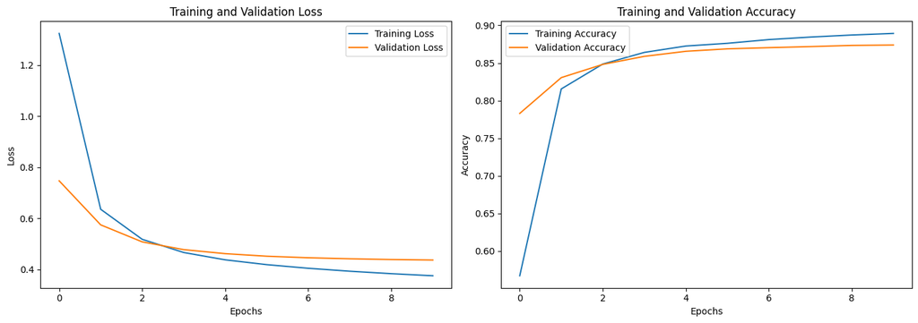

```
Model: "sequential_79"
```

```
┏━━━━━━━━━━━━━━━━━━━━━━━━━━━━━━━━━┳━━━━━━━━━━━━━━━━━━━━━━━━┳━━━━━━━━━━━━━━━┓
┃ Layer (type)                    ┃ Output Shape           ┃       Param # ┃
┡━━━━━━━━━━━━━━━━━━━━━━━━━━━━━━━━━╇━━━━━━━━━━━━━━━━━━━━━━━━╇━━━━━━━━━━━━━━━┩
│ flatten_84 (Flatten)            │ (None, 784)            │             0 │
├─────────────────────────────────┼────────────────────────┼───────────────┤
│ dense_231 (Dense)               │ (None, 16)             │        12,560 │
├─────────────────────────────────┼────────────────────────┼───────────────┤
│ dense_232 (Dense)               │ (None, 16)             │           272 │
├─────────────────────────────────┼────────────────────────┼───────────────┤
│ dense_233 (Dense)               │ (None, 10)             │           170 │
└─────────────────────────────────┴────────────────────────┴───────────────┘
```

```
 Total params: 13,002 (50.79 KB)
```

```
 Trainable params: 13,002 (50.79 KB)
```

```
 Non-trainable params: 0 (0.00 B)
```

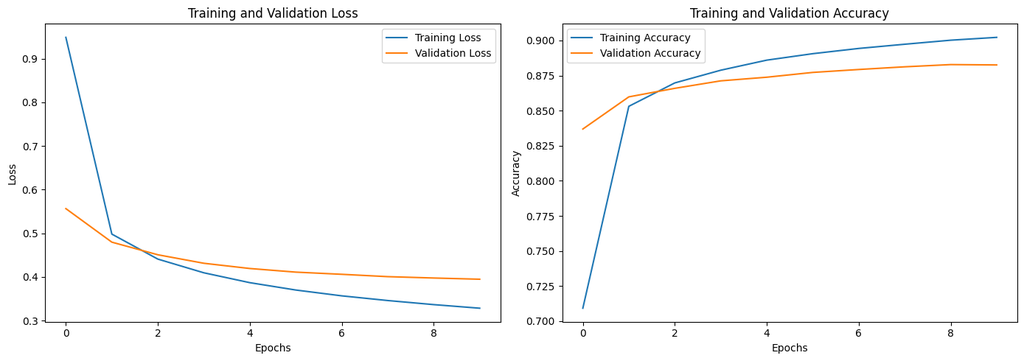

```
Model: "sequential_80"
```

```
┏━━━━━━━━━━━━━━━━━━━━━━━━━━━━━━━━━┳━━━━━━━━━━━━━━━━━━━━━━━━┳━━━━━━━━━━━━━━━┓
┃ Layer (type)                    ┃ Output Shape           ┃       Param # ┃
┡━━━━━━━━━━━━━━━━━━━━━━━━━━━━━━━━━╇━━━━━━━━━━━━━━━━━━━━━━━━╇━━━━━━━━━━━━━━━┩
│ flatten_85 (Flatten)            │ (None, 784)            │             0 │
├─────────────────────────────────┼────────────────────────┼───────────────┤
│ dense_234 (Dense)               │ (None, 32)             │        25,120 │
├─────────────────────────────────┼────────────────────────┼───────────────┤
│ dense_235 (Dense)               │ (None, 16)             │           528 │
├─────────────────────────────────┼────────────────────────┼───────────────┤
│ dense_236 (Dense)               │ (None, 10)             │           170 │
└─────────────────────────────────┴────────────────────────┴───────────────┘
```

```
 Total params: 25,818 (100.85 KB)
```

```
 Trainable params: 25,818 (100.85 KB)
```

```
 Non-trainable params: 0 (0.00 B)
```

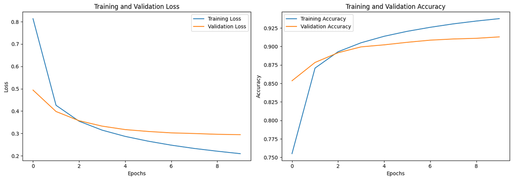

```
Model: "sequential_81"
```

```
┏━━━━━━━━━━━━━━━━━━━━━━━━━━━━━━━━━┳━━━━━━━━━━━━━━━━━━━━━━━━┳━━━━━━━━━━━━━━━┓
┃ Layer (type)                    ┃ Output Shape           ┃       Param # ┃
┡━━━━━━━━━━━━━━━━━━━━━━━━━━━━━━━━━╇━━━━━━━━━━━━━━━━━━━━━━━━╇━━━━━━━━━━━━━━━┩
│ flatten_86 (Flatten)            │ (None, 784)            │             0 │
├─────────────────────────────────┼────────────────────────┼───────────────┤
│ dense_237 (Dense)               │ (None, 32)             │        25,120 │
├─────────────────────────────────┼────────────────────────┼───────────────┤
│ dense_238 (Dense)               │ (None, 32)             │         1,056 │
├─────────────────────────────────┼────────────────────────┼───────────────┤
│ dense_239 (Dense)               │ (None, 10)             │           330 │
└─────────────────────────────────┴────────────────────────┴───────────────┘
```

```
 Total params: 26,506 (103.54 KB)
```

```
 Trainable params: 26,506 (103.54 KB)
```

```
 Non-trainable params: 0 (0.00 B)
```

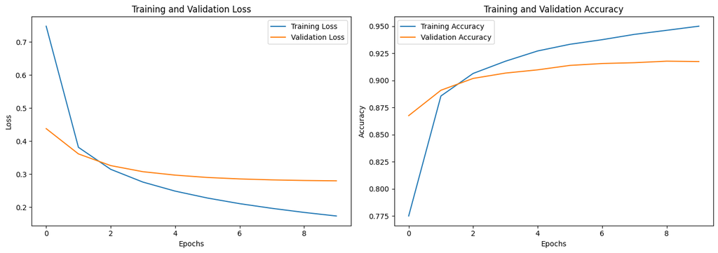

```
Model: "sequential_82"
```

```
┏━━━━━━━━━━━━━━━━━━━━━━━━━━━━━━━━━┳━━━━━━━━━━━━━━━━━━━━━━━━┳━━━━━━━━━━━━━━━┓
┃ Layer (type)                    ┃ Output Shape           ┃       Param # ┃
┡━━━━━━━━━━━━━━━━━━━━━━━━━━━━━━━━━╇━━━━━━━━━━━━━━━━━━━━━━━━╇━━━━━━━━━━━━━━━┩
│ flatten_87 (Flatten)            │ (None, 784)            │             0 │
├─────────────────────────────────┼────────────────────────┼───────────────┤
│ dense_240 (Dense)               │ (None, 64)             │        50,240 │
├─────────────────────────────────┼────────────────────────┼───────────────┤
│ dense_241 (Dense)               │ (None, 32)             │         2,080 │
├─────────────────────────────────┼────────────────────────┼───────────────┤
│ dense_242 (Dense)               │ (None, 10)             │           330 │
└─────────────────────────────────┴────────────────────────┴───────────────┘
```

```
 Total params: 52,650 (205.66 KB)
```

```
 Trainable params: 52,650 (205.66 KB)
```

```
 Non-trainable params: 0 (0.00 B)
```

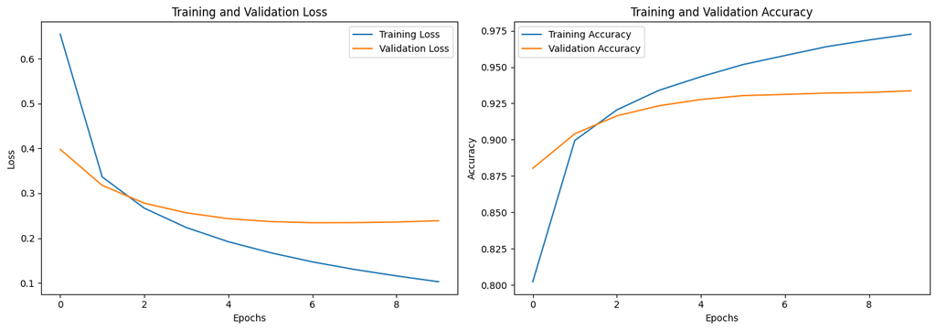

```
Model: "sequential_83"
```

```
┏━━━━━━━━━━━━━━━━━━━━━━━━━━━━━━━━━┳━━━━━━━━━━━━━━━━━━━━━━━━┳━━━━━━━━━━━━━━━┓
┃ Layer (type)                    ┃ Output Shape           ┃       Param # ┃
┡━━━━━━━━━━━━━━━━━━━━━━━━━━━━━━━━━╇━━━━━━━━━━━━━━━━━━━━━━━━╇━━━━━━━━━━━━━━━┩
│ flatten_88 (Flatten)            │ (None, 784)            │             0 │
├─────────────────────────────────┼────────────────────────┼───────────────┤
│ dense_243 (Dense)               │ (None, 64)             │        50,240 │
├─────────────────────────────────┼────────────────────────┼───────────────┤
│ dense_244 (Dense)               │ (None, 64)             │         4,160 │
├─────────────────────────────────┼────────────────────────┼───────────────┤
│ dense_245 (Dense)               │ (None, 10)             │           650 │
└─────────────────────────────────┴────────────────────────┴───────────────┘
```

```
 Total params: 55,050 (215.04 KB)
```

```
 Trainable params: 55,050 (215.04 KB)
```

```
 Non-trainable params: 0 (0.00 B)
```

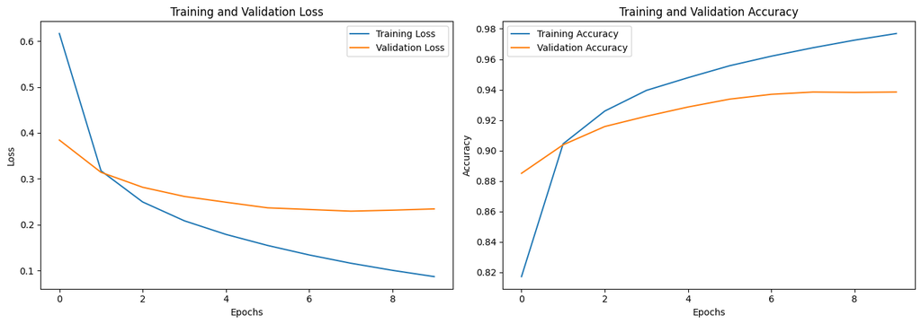

```
Model: "sequential_84"
```

```
┏━━━━━━━━━━━━━━━━━━━━━━━━━━━━━━━━━┳━━━━━━━━━━━━━━━━━━━━━━━━┳━━━━━━━━━━━━━━━┓
┃ Layer (type)                    ┃ Output Shape           ┃       Param # ┃
┡━━━━━━━━━━━━━━━━━━━━━━━━━━━━━━━━━╇━━━━━━━━━━━━━━━━━━━━━━━━╇━━━━━━━━━━━━━━━┩
│ flatten_89 (Flatten)            │ (None, 784)            │             0 │
├─────────────────────────────────┼────────────────────────┼───────────────┤
│ dense_246 (Dense)               │ (None, 128)            │       100,480 │
├─────────────────────────────────┼────────────────────────┼───────────────┤
│ dense_247 (Dense)               │ (None, 64)             │         8,256 │
├─────────────────────────────────┼────────────────────────┼───────────────┤
│ dense_248 (Dense)               │ (None, 10)             │           650 │
└─────────────────────────────────┴────────────────────────┴───────────────┘
```

```
 Total params: 109,386 (427.29 KB)
```

```
 Trainable params: 109,386 (427.29 KB)
```

```
 Non-trainable params: 0 (0.00 B)
```

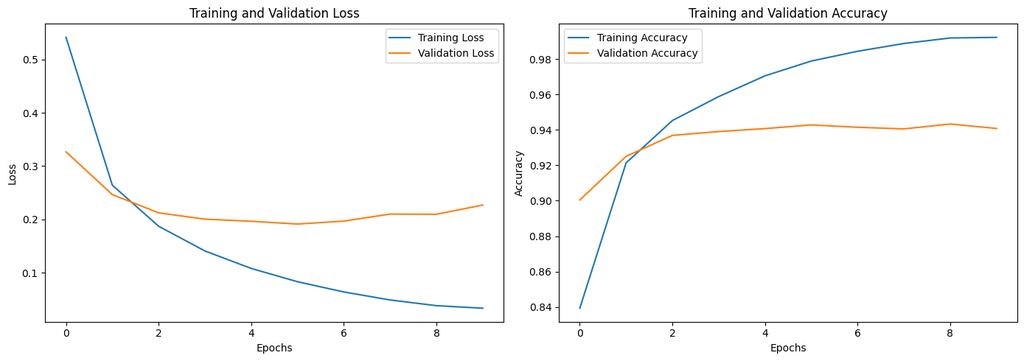

```
Model: "sequential_85"
```

```
┏━━━━━━━━━━━━━━━━━━━━━━━━━━━━━━━━━┳━━━━━━━━━━━━━━━━━━━━━━━━┳━━━━━━━━━━━━━━━┓
┃ Layer (type)                    ┃ Output Shape           ┃       Param # ┃
┡━━━━━━━━━━━━━━━━━━━━━━━━━━━━━━━━━╇━━━━━━━━━━━━━━━━━━━━━━━━╇━━━━━━━━━━━━━━━┩
│ flatten_90 (Flatten)            │ (None, 784)            │             0 │
├─────────────────────────────────┼────────────────────────┼───────────────┤
│ dense_249 (Dense)               │ (None, 128)            │       100,480 │
├─────────────────────────────────┼────────────────────────┼───────────────┤
│ dense_250 (Dense)               │ (None, 128)            │        16,512 │
├─────────────────────────────────┼────────────────────────┼───────────────┤
│ dense_251 (Dense)               │ (None, 10)             │         1,290 │
└─────────────────────────────────┴────────────────────────┴───────────────┘
```

```
 Total params: 118,282 (462.04 KB)
```

```
 Trainable params: 118,282 (462.04 KB)
```

```
 Non-trainable params: 0 (0.00 B)
```

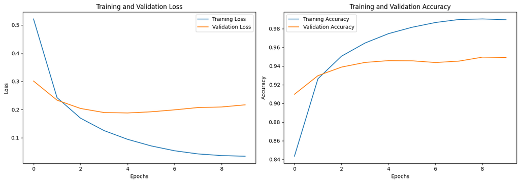

```
Model: "sequential_86"
```

```
┏━━━━━━━━━━━━━━━━━━━━━━━━━━━━━━━━━┳━━━━━━━━━━━━━━━━━━━━━━━━┳━━━━━━━━━━━━━━━┓
┃ Layer (type)                    ┃ Output Shape           ┃       Param # ┃
┡━━━━━━━━━━━━━━━━━━━━━━━━━━━━━━━━━╇━━━━━━━━━━━━━━━━━━━━━━━━╇━━━━━━━━━━━━━━━┩
│ flatten_91 (Flatten)            │ (None, 784)            │             0 │
├─────────────────────────────────┼────────────────────────┼───────────────┤
│ dense_252 (Dense)               │ (None, 256)            │       200,960 │
├─────────────────────────────────┼────────────────────────┼───────────────┤
│ dense_253 (Dense)               │ (None, 128)            │        32,896 │
├─────────────────────────────────┼────────────────────────┼───────────────┤
│ dense_254 (Dense)               │ (None, 10)             │         1,290 │
└─────────────────────────────────┴────────────────────────┴───────────────┘
```

```
 Total params: 235,146 (918.54 KB)
```

```
 Trainable params: 235,146 (918.54 KB)
```

```
 Non-trainable params: 0 (0.00 B)
```

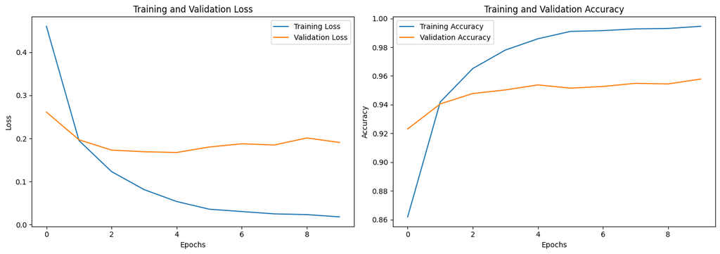

```
Model: "sequential_87"
```

```
┏━━━━━━━━━━━━━━━━━━━━━━━━━━━━━━━━━┳━━━━━━━━━━━━━━━━━━━━━━━━┳━━━━━━━━━━━━━━━┓
┃ Layer (type)                    ┃ Output Shape           ┃       Param # ┃
┡━━━━━━━━━━━━━━━━━━━━━━━━━━━━━━━━━╇━━━━━━━━━━━━━━━━━━━━━━━━╇━━━━━━━━━━━━━━━┩
│ flatten_92 (Flatten)            │ (None, 784)            │             0 │
├─────────────────────────────────┼────────────────────────┼───────────────┤
│ dense_255 (Dense)               │ (None, 256)            │       200,960 │
├─────────────────────────────────┼────────────────────────┼───────────────┤
│ dense_256 (Dense)               │ (None, 256)            │        65,792 │
├─────────────────────────────────┼────────────────────────┼───────────────┤
│ dense_257 (Dense)               │ (None, 10)             │         2,570 │
└─────────────────────────────────┴────────────────────────┴───────────────┘
```

```
 Total params: 269,322 (1.03 MB)
```

```
 Trainable params: 269,322 (1.03 MB)
```

```
 Non-trainable params: 0 (0.00 B)
```

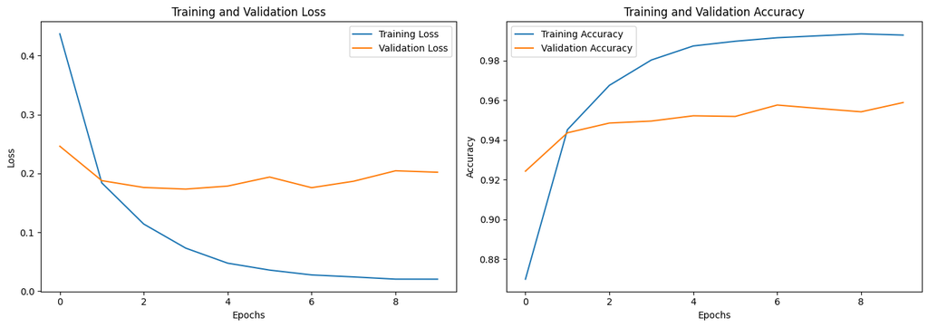

```
Model: "sequential_88"
```

```
┏━━━━━━━━━━━━━━━━━━━━━━━━━━━━━━━━━┳━━━━━━━━━━━━━━━━━━━━━━━━┳━━━━━━━━━━━━━━━┓
┃ Layer (type)                    ┃ Output Shape           ┃       Param # ┃
┡━━━━━━━━━━━━━━━━━━━━━━━━━━━━━━━━━╇━━━━━━━━━━━━━━━━━━━━━━━━╇━━━━━━━━━━━━━━━┩
│ flatten_93 (Flatten)            │ (None, 784)            │             0 │
├─────────────────────────────────┼────────────────────────┼───────────────┤
│ dense_258 (Dense)               │ (None, 512)            │       401,920 │
├─────────────────────────────────┼────────────────────────┼───────────────┤
│ dense_259 (Dense)               │ (None, 256)            │       131,328 │
├─────────────────────────────────┼────────────────────────┼───────────────┤
│ dense_260 (Dense)               │ (None, 10)             │         2,570 │
└─────────────────────────────────┴────────────────────────┴───────────────┘
```

```
 Total params: 535,818 (2.04 MB)
```

```
 Trainable params: 535,818 (2.04 MB)
```

```
 Non-trainable params: 0 (0.00 B)
```

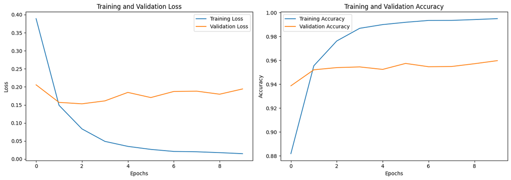

```
Model: "sequential_89"
```

```
┏━━━━━━━━━━━━━━━━━━━━━━━━━━━━━━━━━┳━━━━━━━━━━━━━━━━━━━━━━━━┳━━━━━━━━━━━━━━━┓
┃ Layer (type)                    ┃ Output Shape           ┃       Param # ┃
┡━━━━━━━━━━━━━━━━━━━━━━━━━━━━━━━━━╇━━━━━━━━━━━━━━━━━━━━━━━━╇━━━━━━━━━━━━━━━┩
│ flatten_94 (Flatten)            │ (None, 784)            │             0 │
├─────────────────────────────────┼────────────────────────┼───────────────┤
│ dense_261 (Dense)               │ (None, 512)            │       401,920 │
├─────────────────────────────────┼────────────────────────┼───────────────┤
│ dense_262 (Dense)               │ (None, 512)            │       262,656 │
├─────────────────────────────────┼────────────────────────┼───────────────┤
│ dense_263 (Dense)               │ (None, 10)             │         5,130 │
└─────────────────────────────────┴────────────────────────┴───────────────┘
```

```
 Total params: 669,706 (2.55 MB)
```

```
 Trainable params: 669,706 (2.55 MB)
```

```
 Non-trainable params: 0 (0.00 B)
```

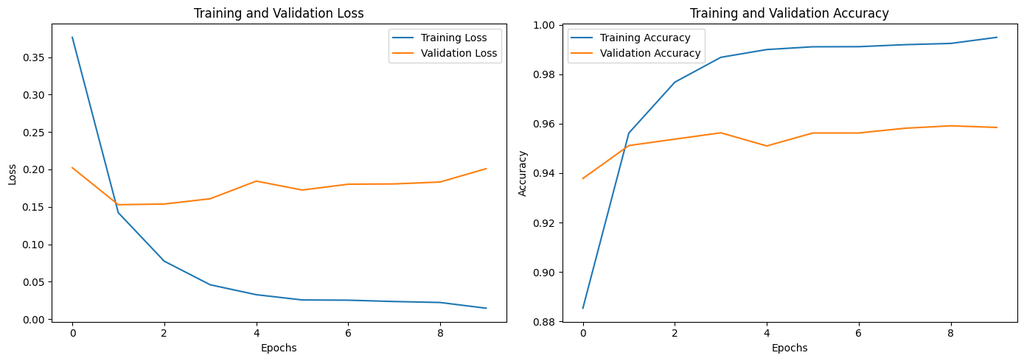

```
Model: "sequential_90"
```

```
┏━━━━━━━━━━━━━━━━━━━━━━━━━━━━━━━━━┳━━━━━━━━━━━━━━━━━━━━━━━━┳━━━━━━━━━━━━━━━┓
┃ Layer (type)                    ┃ Output Shape           ┃       Param # ┃
┡━━━━━━━━━━━━━━━━━━━━━━━━━━━━━━━━━╇━━━━━━━━━━━━━━━━━━━━━━━━╇━━━━━━━━━━━━━━━┩
│ flatten_95 (Flatten)            │ (None, 784)            │             0 │
├─────────────────────────────────┼────────────────────────┼───────────────┤
│ dense_264 (Dense)               │ (None, 1024)           │       803,840 │
├─────────────────────────────────┼────────────────────────┼───────────────┤
│ dense_265 (Dense)               │ (None, 512)            │       524,800 │
├─────────────────────────────────┼────────────────────────┼───────────────┤
│ dense_266 (Dense)               │ (None, 10)             │         5,130 │
└─────────────────────────────────┴────────────────────────┴───────────────┘
```

```
 Total params: 1,333,770 (5.09 MB)
```

```
 Trainable params: 1,333,770 (5.09 MB)
```

```
 Non-trainable params: 0 (0.00 B)
```

[2 more figures not shown]

```python
layer_1_nodes = 16
layer_2_nodes = 8

while layer_1_nodes <= 1024:
    while layer_2_nodes <= layer_1_nodes:
        model, evaluations = compile_fit_evaluate_dnn(
            x_train,
            y_train,
            x_val,
            y_val,
            [
                Dense(layer_1_nodes, activation="relu"),
                Dense(layer_2_nodes, activation="relu"),
            ],
            "adam",
            10,
            evaluations,
            f"{layer_1_nodes}_{layer_2_nodes}_nodes",
        )
        if layer_2_nodes != layer_1_nodes:
            layer_2_nodes *= 2
        else:
            break
    layer_1_nodes *= 2
```

### Epochs

```
Model: "sequential_92"
```

```
┏━━━━━━━━━━━━━━━━━━━━━━━━━━━━━━━━━┳━━━━━━━━━━━━━━━━━━━━━━━━┳━━━━━━━━━━━━━━━┓
┃ Layer (type)                    ┃ Output Shape           ┃       Param # ┃
┡━━━━━━━━━━━━━━━━━━━━━━━━━━━━━━━━━╇━━━━━━━━━━━━━━━━━━━━━━━━╇━━━━━━━━━━━━━━━┩
│ flatten_97 (Flatten)            │ (None, 784)            │             0 │
├─────────────────────────────────┼────────────────────────┼───────────────┤
│ dense_270 (Dense)               │ (None, 8)              │         6,280 │
├─────────────────────────────────┼────────────────────────┼───────────────┤
│ dense_271 (Dense)               │ (None, 8)              │            72 │
├─────────────────────────────────┼────────────────────────┼───────────────┤
│ dense_272 (Dense)               │ (None, 10)             │            90 │
└─────────────────────────────────┴────────────────────────┴───────────────┘
```

```
 Total params: 6,442 (25.16 KB)
```

```
 Trainable params: 6,442 (25.16 KB)
```

```
 Non-trainable params: 0 (0.00 B)
```

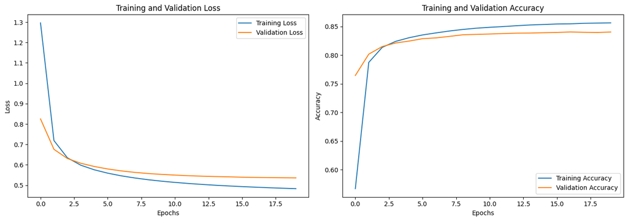

```
Model: "sequential_93"
```

```
┏━━━━━━━━━━━━━━━━━━━━━━━━━━━━━━━━━┳━━━━━━━━━━━━━━━━━━━━━━━━┳━━━━━━━━━━━━━━━┓
┃ Layer (type)                    ┃ Output Shape           ┃       Param # ┃
┡━━━━━━━━━━━━━━━━━━━━━━━━━━━━━━━━━╇━━━━━━━━━━━━━━━━━━━━━━━━╇━━━━━━━━━━━━━━━┩
│ flatten_98 (Flatten)            │ (None, 784)            │             0 │
├─────────────────────────────────┼────────────────────────┼───────────────┤
│ dense_273 (Dense)               │ (None, 8)              │         6,280 │
├─────────────────────────────────┼────────────────────────┼───────────────┤
│ dense_274 (Dense)               │ (None, 8)              │            72 │
├─────────────────────────────────┼────────────────────────┼───────────────┤
│ dense_275 (Dense)               │ (None, 10)             │            90 │
└─────────────────────────────────┴────────────────────────┴───────────────┘
```

```
 Total params: 6,442 (25.16 KB)
```

```
 Trainable params: 6,442 (25.16 KB)
```

```
 Non-trainable params: 0 (0.00 B)
```

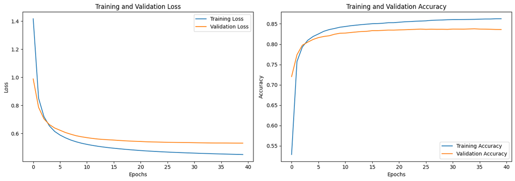

```
Model: "sequential_94"
```

```
┏━━━━━━━━━━━━━━━━━━━━━━━━━━━━━━━━━┳━━━━━━━━━━━━━━━━━━━━━━━━┳━━━━━━━━━━━━━━━┓
┃ Layer (type)                    ┃ Output Shape           ┃       Param # ┃
┡━━━━━━━━━━━━━━━━━━━━━━━━━━━━━━━━━╇━━━━━━━━━━━━━━━━━━━━━━━━╇━━━━━━━━━━━━━━━┩
│ flatten_99 (Flatten)            │ (None, 784)            │             0 │
├─────────────────────────────────┼────────────────────────┼───────────────┤
│ dense_276 (Dense)               │ (None, 8)              │         6,280 │
├─────────────────────────────────┼────────────────────────┼───────────────┤
│ dense_277 (Dense)               │ (None, 8)              │            72 │
├─────────────────────────────────┼────────────────────────┼───────────────┤
│ dense_278 (Dense)               │ (None, 10)             │            90 │
└─────────────────────────────────┴────────────────────────┴───────────────┘
```

```
 Total params: 6,442 (25.16 KB)
```

```
 Trainable params: 6,442 (25.16 KB)
```

```
 Non-trainable params: 0 (0.00 B)
```

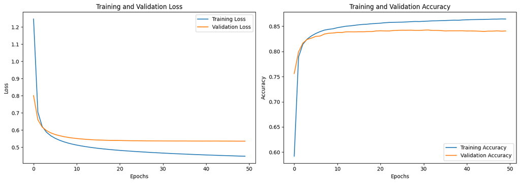

```
Model: "sequential_95"
```

```
┏━━━━━━━━━━━━━━━━━━━━━━━━━━━━━━━━━┳━━━━━━━━━━━━━━━━━━━━━━━━┳━━━━━━━━━━━━━━━┓
┃ Layer (type)                    ┃ Output Shape           ┃       Param # ┃
┡━━━━━━━━━━━━━━━━━━━━━━━━━━━━━━━━━╇━━━━━━━━━━━━━━━━━━━━━━━━╇━━━━━━━━━━━━━━━┩
│ flatten_100 (Flatten)           │ (None, 784)            │             0 │
├─────────────────────────────────┼────────────────────────┼───────────────┤
│ dense_279 (Dense)               │ (None, 8)              │         6,280 │
├─────────────────────────────────┼────────────────────────┼───────────────┤
│ dense_280 (Dense)               │ (None, 8)              │            72 │
├─────────────────────────────────┼────────────────────────┼───────────────┤
│ dense_281 (Dense)               │ (None, 10)             │            90 │
└─────────────────────────────────┴────────────────────────┴───────────────┘
```

```
 Total params: 6,442 (25.16 KB)
```

```
 Trainable params: 6,442 (25.16 KB)
```

```
 Non-trainable params: 0 (0.00 B)
```

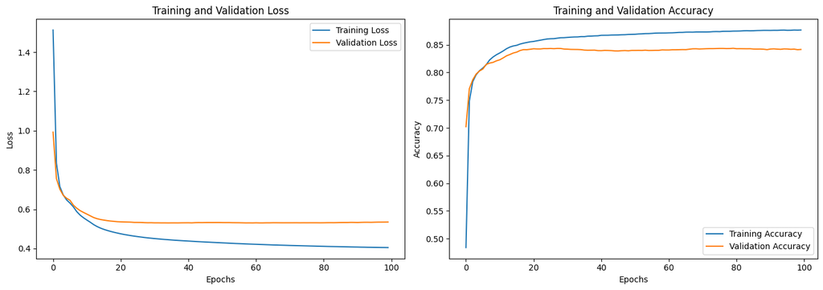

```python
epochs = [20, 40, 50, 100]

for epoch in epochs:
    model, evaluations = compile_fit_evaluate_dnn(
        x_train,
        y_train,
        x_val,
        y_val,
        [
            Dense(8, activation="relu"),
            Dense(8, activation="relu"),
        ],
        "adam",
        epoch,
        evaluations,
        f"{epoch}_epochs",
    )
```

```python
for key, metrics in evaluations.items():
    print(f"Key: {key}, Loss: {metrics['loss']}, Accuracy: {metrics['accuracy']}")
```

```
Key: baseline, Loss: 0.6088229417800903, Accuracy: 0.8152499794960022
Key: sgd_DNN, Loss: 0.8441494703292847, Accuracy: 0.746999979019165
Key: rmsprop_DNN, Loss: 0.6105672717094421, Accuracy: 0.8149166703224182
Key: adagrad_DNN, Loss: 1.6236475706100464, Accuracy: 0.4779166579246521
Key: adadelta_DNN, Loss: 2.2908706665039062, Accuracy: 0.13766667246818542
Key: adamax_DNN, Loss: 0.7117962837219238, Accuracy: 0.7870000004768372
Key: nadam_DNN, Loss: 0.6009641289710999, Accuracy: 0.8191666603088379
Key: ftrl_DNN, Loss: 2.3025856018066406, Accuracy: 0.10000000149011612
Key: 0_hidden_layers_DNN, Loss: 0.6116966009140015, Accuracy: 0.8221666812896729
Key: 1_hidden_layer_DNN, Loss: 0.5988820195198059, Accuracy: 0.8230833411216736
Key: 3_hidden_layers_DNN, Loss: 0.5994929075241089, Accuracy: 0.815750002861023
Key: 16_8_nodes_DNN, Loss: 0.43638935685157776, Accuracy: 0.8738333582878113
Key: 16_16_nodes_DNN, Loss: 0.3946201503276825, Accuracy: 0.8825833201408386
Key: 32_16_nodes_DNN, Loss: 0.294381707906723, Accuracy: 0.9129166603088379
Key: 32_32_nodes_DNN, Loss: 0.2795566916465759, Accuracy: 0.9175000190734863
Key: 64_32_nodes_DNN, Loss: 0.23874759674072266, Accuracy: 0.9336666464805603
Key: 64_64_nodes_DNN, Loss: 0.2342098355293274, Accuracy: 0.9384166598320007
Key: 128_64_nodes_DNN, Loss: 0.22708341479301453, Accuracy: 0.940833330154419
Key: 128_128_nodes_DNN, Loss: 0.2164769470691681, Accuracy: 0.9490000009536743
Key: 256_128_nodes_DNN, Loss: 0.19068801403045654, Accuracy: 0.9578333497047424
Key: 256_256_nodes_DNN, Loss: 0.20206591486930847, Accuracy: 0.9589166641235352
Key: 512_256_nodes_DNN, Loss: 0.19422873854637146, Accuracy: 0.9597499966621399
Key: 512_512_nodes_DNN, Loss: 0.20097661018371582, Accuracy: 0.9585000276565552
Key: 1024_512_nodes_DNN, Loss: 0.18581123650074005, Accuracy: 0.9616666436195374
Key: 1024_1024_nodes_DNN, Loss: 0.20344480872154236, Accuracy: 0.9592499732971191
Key: 20_epochs_DNN, Loss: 0.5357072353363037, Accuracy: 0.840416669845581
Key: 40_epochs_DNN, Loss: 0.5309807658195496, Accuracy: 0.8360833525657654
Key: 50_epochs_DNN, Loss: 0.5348911285400391, Accuracy: 0.840666651725769
Key: 100_epochs_DNN, Loss: 0.5348130464553833, Accuracy: 0.8415833115577698
```

```
Model: "sequential_3"
```

```
┏━━━━━━━━━━━━━━━━━━━━━━━━━━━━━━━━━┳━━━━━━━━━━━━━━━━━━━━━━━━┳━━━━━━━━━━━━━━━┓
┃ Layer (type)                    ┃ Output Shape           ┃       Param # ┃
┡━━━━━━━━━━━━━━━━━━━━━━━━━━━━━━━━━╇━━━━━━━━━━━━━━━━━━━━━━━━╇━━━━━━━━━━━━━━━┩
│ flatten_4 (Flatten)             │ (None, 784)            │             0 │
├─────────────────────────────────┼────────────────────────┼───────────────┤
│ dense_11 (Dense)                │ (None, 512)            │       401,920 │
├─────────────────────────────────┼────────────────────────┼───────────────┤
│ dense_12 (Dense)                │ (None, 512)            │       262,656 │
├─────────────────────────────────┼────────────────────────┼───────────────┤
│ dense_13 (Dense)                │ (None, 10)             │         5,130 │
└─────────────────────────────────┴────────────────────────┴───────────────┘
```

```
 Total params: 669,706 (2.55 MB)
```

```
 Trainable params: 669,706 (2.55 MB)
```

```
 Non-trainable params: 0 (0.00 B)
```

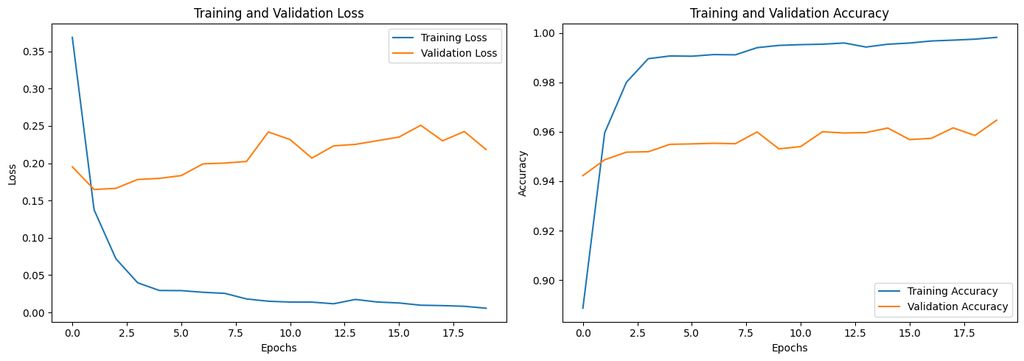

```python
model, evaluations = compile_fit_evaluate_dnn(
    x_train,
    y_train,
    x_val,
    y_val,
    [
        Dense(512, activation="relu"),
        Dense(512, activation="relu"),
    ],
    "nadam",
    20,
    evaluations,
    "512_512_nodes_nadam",
)
```

```python
for key, metrics in evaluations.items():
    print(f"Key: {key}, Loss: {metrics['loss']}, Accuracy: {metrics['accuracy']}")
```

[output not shown]

*Finally, evaluate your model on the test set. Report overall accuracy, per-class accuracies, and display a confusion matrix.*

```
1875/1875 ━━━━━━━━━━━━━━━━━━━━ 2s 1ms/step
1875/1875 ━━━━━━━━━━━━━━━━━━━━ 3s 1ms/step - accuracy: 0.9912 - loss: 0.0471
Test Loss: 0.0474
Test Accuracy: 0.9916
              precision    recall  f1-score   support

           0       1.00      0.99      1.00      6000
           1       0.99      0.99      0.99      6000
           2       0.99      0.99      0.99      6000
           3       0.99      1.00      0.99      6000
           4       0.99      0.99      0.99      6000
           5       0.99      0.99      0.99      6000
           6       0.99      0.99      0.99      6000
           7       0.99      1.00      1.00      6000
           8       0.99      0.99      0.99      6000
           9       1.00      0.99      0.99      6000

    accuracy                           0.99     60000
   macro avg       0.99      0.99      0.99     60000
weighted avg       0.99      0.99      0.99     60000
```

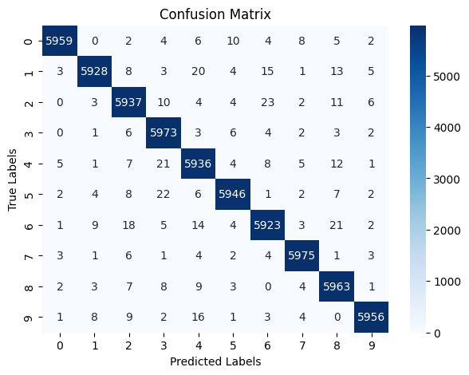

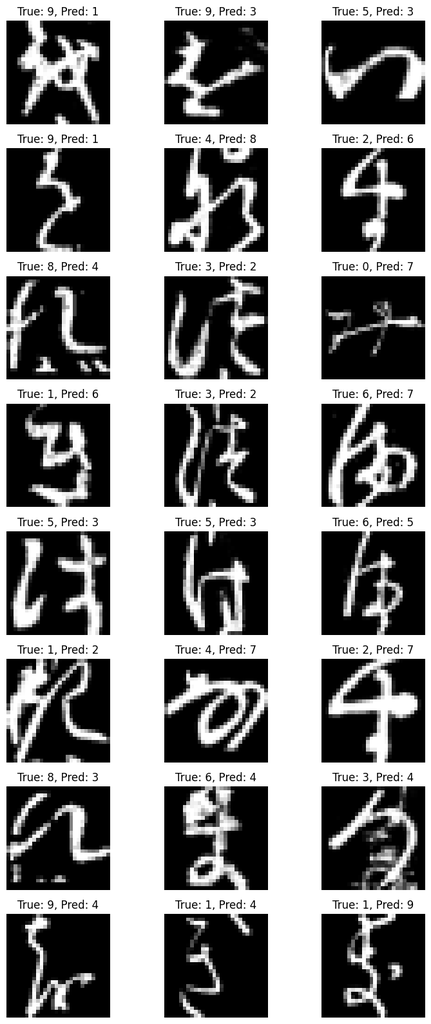

```python
test_predict_evaluate(x_test, y_test, model)
```

### Implement a (small) Convolutional Neural Network

*Review the convolutional layer and max pooling layer options in the Keras API documentation. In particular, look at the input shapes and determine what type of convolutional and max pooling layers are most appropriate for the dimensionality of your data.*

The input shapes is (28, 28, 1) indicating that there are two spatial dimensions. Therefore Conv2D and MaxPooling2D are most appropriate.

*Implement a neural network using the Keras Sequential API with:*

```python
cnn_model = models.Sequential()
```

1. *input layer*

```python
cnn_model.add(InputLayer(input_shape=(28, 28, 1)))
```

2. *2 convolutional layers (ReLU)*

```python
cnn_model.add(Conv2D(8, kernel_size=(2, 2), activation='relu'))
cnn_model.add(Conv2D(16, kernel_size=(2, 2), activation='relu'))
```

3. *1 max pooling layer with a 2x2 pool size*

```python
cnn_model.add(MaxPooling2D(pool_size=(2, 2)))
```

4. *1 flatten layer*

```python
cnn_model.add(Flatten())
```

5. *2 dense layers (ReLU) – use optimized parameter choices from the MLP*

```python
cnn_model.add(Dense(512, activation='relu'))
cnn_model.add(Dense(512, activation='relu'))
```

6. *1 dense layer with 10 nodes (1 for each output class, w/ softmax)*

```python
cnn_model.add(Dense(10, activation='softmax'))
```

*As before, have the model report accuracy as one of the metrics.*

```python
cnn_model.compile(optimizer='adam', loss='categorical_crossentropy', metrics=['accuracy'])
```

*Output a summary of the model architecture using the summary() method.*

```python
cnn_model.summary()
```

```
Model: "sequential"
```

```
┏━━━━━━━━━━━━━━━━━━━━━━━━━━━━━━━━━┳━━━━━━━━━━━━━━━━━━━━━━━━┳━━━━━━━━━━━━━━━┓
┃ Layer (type)                    ┃ Output Shape           ┃       Param # ┃
┡━━━━━━━━━━━━━━━━━━━━━━━━━━━━━━━━━╇━━━━━━━━━━━━━━━━━━━━━━━━╇━━━━━━━━━━━━━━━┩
│ conv2d_2 (Conv2D)               │ (None, 27, 27, 8)      │            40 │
├─────────────────────────────────┼────────────────────────┼───────────────┤
│ conv2d_3 (Conv2D)               │ (None, 26, 26, 16)     │           528 │
├─────────────────────────────────┼────────────────────────┼───────────────┤
│ max_pooling2d_2 (MaxPooling2D)  │ (None, 13, 13, 16)     │             0 │
├─────────────────────────────────┼────────────────────────┼───────────────┤
│ flatten_1 (Flatten)             │ (None, 2704)           │             0 │
├─────────────────────────────────┼────────────────────────┼───────────────┤
│ dense_2 (Dense)                 │ (None, 512)            │     1,384,960 │
├─────────────────────────────────┼────────────────────────┼───────────────┤
│ dense_3 (Dense)                 │ (None, 512)            │       262,656 │
├─────────────────────────────────┼────────────────────────┼───────────────┤
│ dense_4 (Dense)                 │ (None, 10)             │         5,130 │
└─────────────────────────────────┴────────────────────────┴───────────────┘
```

```
 Total params: 1,653,314 (6.31 MB)
```

```
 Trainable params: 1,653,314 (6.31 MB)
```

```
 Non-trainable params: 0 (0.00 B)
```

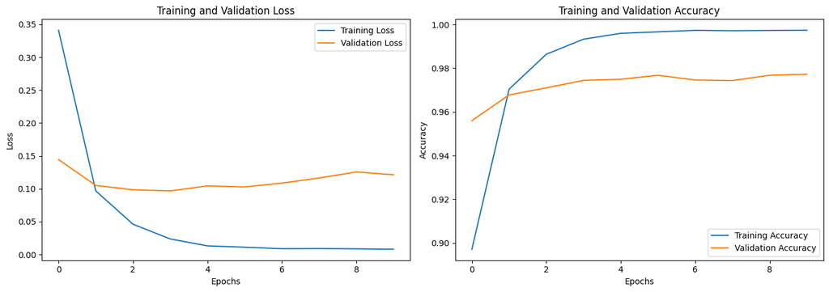

```python
fit_visualize_convergence(cnn_model, x_train, y_train, x_val, y_val, epochs=10)
```

```python
evaluate_record_metrics(cnn_model, x_val, y_val, evaluations, 'cnn_baseline')
```

```python
for key, metrics in evaluations.items():
    print(f"Key: {key}, Loss: {metrics['loss']}, Accuracy: {metrics['accuracy']}")
```

```
Key: baseline, Loss: 0.6088229417800903, Accuracy: 0.8152499794960022
Key: sgd_DNN, Loss: 0.8441494703292847, Accuracy: 0.746999979019165
Key: rmsprop_DNN, Loss: 0.6105672717094421, Accuracy: 0.8149166703224182
Key: adagrad_DNN, Loss: 1.6236475706100464, Accuracy: 0.4779166579246521
Key: adadelta_DNN, Loss: 2.2908706665039062, Accuracy: 0.13766667246818542
Key: adamax_DNN, Loss: 0.7117962837219238, Accuracy: 0.7870000004768372
Key: nadam_DNN, Loss: 0.6009641289710999, Accuracy: 0.8191666603088379
Key: ftrl_DNN, Loss: 2.3025856018066406, Accuracy: 0.10000000149011612
Key: 0_hidden_layers_DNN, Loss: 0.6116966009140015, Accuracy: 0.8221666812896729
Key: 1_hidden_layer_DNN, Loss: 0.5988820195198059, Accuracy: 0.8230833411216736
Key: 3_hidden_layers_DNN, Loss: 0.5994929075241089, Accuracy: 0.815750002861023
Key: 16_8_nodes_DNN, Loss: 0.43638935685157776, Accuracy: 0.8738333582878113
Key: 16_16_nodes_DNN, Loss: 0.3946201503276825, Accuracy: 0.8825833201408386
Key: 32_16_nodes_DNN, Loss: 0.294381707906723, Accuracy: 0.9129166603088379
Key: 32_32_nodes_DNN, Loss: 0.2795566916465759, Accuracy: 0.9175000190734863
Key: 64_32_nodes_DNN, Loss: 0.23874759674072266, Accuracy: 0.9336666464805603
Key: 64_64_nodes_DNN, Loss: 0.2342098355293274, Accuracy: 0.9384166598320007
Key: 128_64_nodes_DNN, Loss: 0.22708341479301453, Accuracy: 0.940833330154419
Key: 128_128_nodes_DNN, Loss: 0.2164769470691681, Accuracy: 0.9490000009536743
Key: 256_128_nodes_DNN, Loss: 0.19068801403045654, Accuracy: 0.9578333497047424
Key: 256_256_nodes_DNN, Loss: 0.20206591486930847, Accuracy: 0.9589166641235352
Key: 512_256_nodes_DNN, Loss: 0.19422873854637146, Accuracy: 0.9597499966621399
Key: 512_512_nodes_DNN, Loss: 0.20097661018371582, Accuracy: 0.9585000276565552
Key: 1024_512_nodes_DNN, Loss: 0.18581123650074005, Accuracy: 0.9616666436195374
Key: 1024_1024_nodes_DNN, Loss: 0.20344480872154236, Accuracy: 0.9592499732971191
Key: 20_epochs_DNN, Loss: 0.5357072353363037, Accuracy: 0.840416669845581
Key: 40_epochs_DNN, Loss: 0.5309807658195496, Accuracy: 0.8360833525657654
Key: 50_epochs_DNN, Loss: 0.5348911285400391, Accuracy: 0.840666651725769
Key: 100_epochs_DNN, Loss: 0.5348130464553833, Accuracy: 0.8415833115577698
Key: 512_512_nodes_nadam_DNN, Loss: 0.19148127734661102, Accuracy: 0.9605000019073486
Key: cnn_baseline, Loss: 0.12665583193302155, Accuracy: 0.9759166836738586
```

*Optimize the validation accuracy of the model by trying different choices of:*

1. *The optimizer*